# Project: The performance of world economy and Its major contributors

- Introduction
- Data Wrangling
- Exploratory Data Analysis
- Conclusions

## Introduction

Every human oprates in a system of global economy which include: production, consumption, economic management, work in general, exchange of financial values and trade of goods and services within and outside their countries. The aim of this project is to review our collective performances over the years seeing that we have come a long way

### Dataset Description

The data we would be using to explore how the world economy has performed over the years is a public dataset and it is available for dowload on [Gap Minder](https://gapminder.org/data/). However, there was no comprehensive data detailing the countries and their continents on [Gap Minder](https://gapminder.org/data/) which was why the `continents'` dataset was sourced from [Our World in Data](https://ourworldindata.org/grapher/continents-according-to-our-world-in-data)

### Data Dictionary

- `country`: The countries of the world
- `continent`: The continents of the world
- `year` : The year for each record
- `agro`: Expressed as a percentage of GDP. It respresents the value of agricultural products delivered to the world
- `import`:Expressed as a percentage of GDP and it respresents the value of goods and other market services recieved from the rest of the world
- `Export`: Expressed as a percentage of GDP and it respresents the value of goods and other market services delivered to the rest of the world
- `investment`:Expressed as a percentage of GDP and it respresents the value financial services delivered to the rest of the world
- `industry`: Expressed as a percentage of GDP and it respresents the value of industrial products delivered to the world
- `Services`: Expressed as a percentage of GDP and it respresents the value Services delivered to the world
- `gdp`: Gross Domestic Product converted to international Dollar using power parity rate

**N:B** The above listed columns are contained in cleaned dataset

### Questions for Analysis

1. How has the world economy performed over the years?
2. What is the general trend displayed by all continents?
3. How do they differ in economic activites?

```python
#import all the neccessary packages and styles for the project
import pandas as pd
import numpy as np
import matplotlib.pyplot as plt
import seaborn as sns

%matplotlib inline
plt.style.use('default')
```

```python
#create list of all the csv files to be read into pandas
dataset=[
    "agriculture_percent_of_gdp.csv",
    "continents-according-to-our-world-in-data.csv",
    "exports_percent_of_gdp.csv",
    "imports_percent_of_gdp.csv",
    "industry_percent_of_gdp.csv",
    "investments_percent_of_gdp.csv",
    "services_percent_of_gdp.csv",
    "total_gdp_ppp_inflation_adjusted.csv"
]
```

```python
# the function reads csv files according to its index
def load(data,num):
    """reads all the csv files"""
    return pd.read_csv(data[num])


#Load all the dataset
agric_df=load(dataset,0)
geo_df=load(dataset,1)
export_df=load(dataset,2)
import_df=load(dataset,3)
industry_df=load(dataset,4)
investment_df=load(dataset,5)
services_df=load(dataset,6)
gdp_df=load(dataset,7)

agric_df.head(2)
```

|  | country | 1960 | 1961 | 1962 | 1963 | 1964 | 1965 | 1966 | 1967 | 1968 | ... | 2011 | 2012 | 2013 | 2014 | 2015 | 2016 | 2017 | 2018 | 2019 | 2020 |
| --- | --- | --- | --- | --- | --- | --- | --- | --- | --- | --- | --- | --- | --- | --- | --- | --- | --- | --- | --- | --- | --- |
| 0 | Aruba | NaN | NaN | NaN | NaN | NaN | NaN | NaN | NaN | NaN | ... | NaN | NaN | NaN | NaN | NaN | NaN | NaN | NaN | NaN | NaN |
| 1 | Afghanistan | NaN | NaN | NaN | NaN | NaN | NaN | NaN | NaN | NaN | ... | 23.7 | 24.4 | 22.8 | 22.1 | 20.6 | 25.7 | 26.4 | 22.0 | 25.8 | 27.0 |

2 rows × 62 columns

### The need to transpose

Majority of all the datset are in wide format as shown above. Hence the need to transpose them. In pandas, the melt() function does the trick.

```python
#create a function that performs the melts the operation
def transpose(df,var):
    df=pd.melt(df, id_vars='country', var_name='year', value_name=var)
    return(df)

#*********************************************************************#
#melt the dataset accordingly
agric_df=transpose(agric_df,"agro")
export_df=transpose(export_df,"export")
import_df=transpose(import_df,"import")
industry_df=transpose(industry_df,"industry")
investment_df=transpose(investment_df,'investment')
services_df=transpose(services_df,"services")
gdp_df=transpose(gdp_df,"gdp")
gdp_df.tail()
```

|  | country | year | gdp |
| --- | --- | --- | --- |
| 49001 | Samoa | 2013 | 915M |
| 49002 | Yemen | 2013 | 109B |
| 49003 | South Africa | 2013 | 614B |
| 49004 | Zambia | 2013 | 44B |
| 49005 | Zimbabwe | 2013 | 19.3B |

```python
geo_df.head(2)#preview dataset
```

|  | Entity | Code | Year | Continent |
| --- | --- | --- | --- | --- |
| 0 | Abkhazia | OWID_ABK | 2015 | Asia |
| 1 | Afghanistan | AFG | 2015 | Asia |

### Merge all dataset together

All the data read into pandas will be merged into a single dataframe using "inner join."

**similarities in the dataset**

- `geo_df` has column "Entity" which is equivalent to 'country' column in `agric_df`.
- The others have "country" and "year" in common as columns

The `geo_df` and `agric_df` will be merged first and separately. The resulting dataframe will then be merged with others

```python
#use inner join to merg agro_df and geo_df
df=pd.merge(agric_df,geo_df[["Entity","Continent"]],right_on="Entity",left_on="country").drop(columns=["Entity"])
data_set=[import_df,export_df,industry_df,investment_df,services_df,gdp_df]
```

```python
#create a function that merges all other dataset at once
def merge(df,others):
    for i,v in enumerate(others):
        df=pd.merge(df,others[i],on=['country','year'])
    return df

merged_df=merge(df,data_set)
merged_df.head()
```

|  | country | year | agro | Continent | import | export | industry | investment | services | gdp |
| --- | --- | --- | --- | --- | --- | --- | --- | --- | --- | --- |
| 0 | Aruba | 1960 | NaN | North America | NaN | NaN | NaN | NaN | NaN | 274M |
| 1 | Aruba | 1961 | NaN | North America | NaN | NaN | NaN | NaN | NaN | 287M |
| 2 | Aruba | 1962 | NaN | North America | NaN | NaN | NaN | NaN | NaN | 298M |
| 3 | Aruba | 1963 | NaN | North America | NaN | NaN | NaN | NaN | NaN | 308M |
| 4 | Aruba | 1964 | NaN | North America | NaN | NaN | NaN | NaN | NaN | 317M |

## Data Wrangling

At a glance the data looks too dirty. There are lots of empty entries which are not useful in the analysis. Their presence will only cause more harm than good. Hence, the need to sort out the NaN and subsequently get the data to be clean

At this point, it is necessary to stress that the GDP, `"gdp" column` is the dependent variable. Any empty cell there will not be tolerated. As such, they will be dropped.

Likewise, all the rows in which all the following variables,`agro, import, export, investment, services` are empty will be dropped.

### Data Cleaning

```python
#
merged_df.info()
```

```
<class 'pandas.core.frame.DataFrame'>
Int64Index: 9126 entries, 0 to 9125
Data columns (total 10 columns):
 #   Column      Non-Null Count  Dtype
---  ------      --------------  -----
 0   country     9126 non-null   object
 1   year        9126 non-null   object
 2   agro        5970 non-null   float64
 3   Continent   9126 non-null   object
 4   import      6556 non-null   float64
 5   export      6547 non-null   float64
 6   industry    5909 non-null   float64
 7   investment  6407 non-null   object
 8   services    5571 non-null   float64
 9   gdp         9029 non-null   object
dtypes: float64(5), object(5)
memory usage: 784.3+ KB
```

```python
#drop a rows with the 5 columns empty at a time
merged_data=merged_df.dropna(axis=0,how="all",subset=["agro","import","export","investment","services"]).reset_index(drop=True)
merged_data.rename(columns={"Continent":"continent"},inplace=True)
merged_data.head()
```

|  | country | year | agro | continent | import | export | industry | investment | services | gdp |
| --- | --- | --- | --- | --- | --- | --- | --- | --- | --- | --- |
| 0 | Aruba | 1995 | 0.506 | North America | 86.5 | 84.9 | 15.4 | 31.1 | 81.0 | 3.1B |
| 1 | Aruba | 1996 | 0.486 | North America | 88.7 | 86.6 | 15.0 | 28.5 | 81.0 | 3.16B |
| 2 | Aruba | 1997 | 0.430 | North America | 86.2 | 82.5 | 17.1 | 30.2 | 79.6 | 3.43B |
| 3 | Aruba | 1998 | 0.408 | North America | 83.6 | 79.7 | 17.5 | 31.7 | 79.5 | 3.7B |
| 4 | Aruba | 1999 | 0.383 | North America | 84.6 | 79.9 | 15.5 | 30.9 | 80.9 | 3.76B |

### Inspecting data before further cleaning

As previewed above, The empty cells seems to have all gone. It is a big fat **NO**. Just the first few rows of the entire data that were previewed. The data will be subjected to further inspection to know what next to clean. However, we can see that the `gdp` columns contains characters. the B means "billion". Also, the `contentent` and `region` were not entered appropriately.

**UP NEXT,** We make changes to the data based on the following observations:

```python
merged_df=merged_data.copy()# make a copy of the dataset before further cleaning
merged_df['continent']=merged_df['continent'].str.title()#convert column to sentence case
merged_df['continent'].value_counts()#check if changes have been made
```

```
Africa           2085
Asia             1626
Europe           1330
North America     892
South America     646
Oceania           315
Name: continent, dtype: int64
```

### Cleaning GDP column

Figures are designated in Millions, Billions, and Trillions as the case may be.Hence need to extract and multiply `dgp` appropriately

```python
#target the Characters in the GDP column and split it to other columns
merged_df[["gdp_fig","unit_char","empty_cells"]]=merged_df['gdp'].str.split(r'([a-zA-Z]+)',expand=True,n=1)
merged_df.head()
```

|  | country | year | agro | continent | import | export | industry | investment | services | gdp | gdp_fig | unit_char | empty_cells |
| --- | --- | --- | --- | --- | --- | --- | --- | --- | --- | --- | --- | --- | --- |
| 0 | Aruba | 1995 | 0.506 | North America | 86.5 | 84.9 | 15.4 | 31.1 | 81.0 | 3.1B | 3.1 | B |  |
| 1 | Aruba | 1996 | 0.486 | North America | 88.7 | 86.6 | 15.0 | 28.5 | 81.0 | 3.16B | 3.16 | B |  |
| 2 | Aruba | 1997 | 0.430 | North America | 86.2 | 82.5 | 17.1 | 30.2 | 79.6 | 3.43B | 3.43 | B |  |
| 3 | Aruba | 1998 | 0.408 | North America | 83.6 | 79.7 | 17.5 | 31.7 | 79.5 | 3.7B | 3.7 | B |  |
| 4 | Aruba | 1999 | 0.383 | North America | 84.6 | 79.9 | 15.5 | 30.9 | 80.9 | 3.76B | 3.76 | B |  |

```python
# B-Billion,M-Million,TR-Trillion
dic = {
    'B': '1000000000',
    'TR': '1000000000000',
    'M': '1000000'
}

merged_df['gdp_format'] = merged_df['unit_char'].replace(dic).astype(float)
merged_df['gdp_format']=merged_df['gdp_fig'].astype(float)*merged_df['gdp_format']
merged_df.drop(columns=["gdp","gdp_fig","unit_char","empty_cells"],inplace=True)
```

### data cleaning bothering on outliers, data types and null values(NaN)

1. All numeric data in our data are expressed in percentage except `gdp` and `year`. As such, any value **>=100** is not realistic. Besides, no country has been reported to have achieved such milestone in many years.
2. check all data types
3. Fill NaN with the mean of their their respective countries.
4. And lastly, any NaN after step 3 will be dropped eventually

```python
#get snapshot of the data
merged_df.describe()
```

|  | agro | import | export | industry | services | gdp_format |
| --- | --- | --- | --- | --- | --- | --- |
| count | 5970.000000 | 6556.000000 | 6547.000000 | 5909.000000 | 5571.000000 | 6.865000e+03 |
| mean | 17.581217 | 38.733205 | 33.860979 | 27.552484 | 48.959725 | 3.296225e+11 |
| std | 14.872686 | 25.359507 | 25.388497 | 12.454565 | 12.435530 | 1.130151e+12 |
| min | 0.033300 | 0.000000 | 0.005380 | 2.370000 | 4.790000 | 9.350000e+07 |
| 25% | 5.202500 | 22.200000 | 16.900000 | 19.600000 | 40.400000 | 9.610000e+09 |
| 50% | 13.500000 | 32.100000 | 27.300000 | 25.700000 | 49.000000 | 3.640000e+10 |
| 75% | 27.200000 | 49.425000 | 44.300000 | 32.600000 | 57.300000 | 2.070000e+11 |
| max | 89.400000 | 236.000000 | 229.000000 | 90.500000 | 98.600000 | 1.640000e+13 |

```python
#filter out all export and import observations greater than or equal to 100%
filtered_import=merged_df[merged_df['import']<100]
filtered_df=filtered_import[filtered_import['export']<100]
fifiltered_df=filtered_import[filtered_import['export']<100]
new_df=filtered_df.reset_index(drop=True)
new_df.describe()
```

|  | agro | import | export | industry | services | gdp_format |
| --- | --- | --- | --- | --- | --- | --- |
| count | 5457.000000 | 6353.000000 | 6353.000000 | 5396.000000 | 5090.000000 | 6.324000e+03 |
| mean | 17.881438 | 35.959719 | 31.296983 | 27.474325 | 48.704898 | 3.537312e+11 |
| std | 14.765210 | 19.236728 | 19.052423 | 12.191047 | 11.981703 | 1.173572e+12 |
| min | 0.094200 | 0.000000 | 0.005380 | 2.370000 | 4.790000 | 9.350000e+07 |
| 25% | 5.510000 | 21.800000 | 16.600000 | 19.800000 | 40.600000 | 1.070000e+10 |
| 50% | 14.100000 | 31.400000 | 26.800000 | 25.700000 | 49.000000 | 4.260000e+10 |
| 75% | 27.400000 | 47.500000 | 42.700000 | 32.300000 | 56.800000 | 2.320000e+11 |
| max | 89.400000 | 99.900000 | 99.900000 | 90.500000 | 90.700000 | 1.640000e+13 |

### Change data types

The `year` and `investment` are not in the right format. They would be converted to type `int` and `float` respectively. Howver, the `investment` column has a character that will hinder the conversion which must be removed or replaced

```python
new_df['year']=new_df['year'].astype(int) #convert to type int
new_df['investment'] = new_df['investment'].str.replace('−', '-') #replace

new_df['investment']=new_df['investment'].astype(float)
new_df=new_df.dropna(axis=0,how="all",subset=["gdp_format"]).reset_index()
new_df.dtypes
```

```
index           int64
country        object
year            int32
agro          float64
continent      object
import        float64
export        float64
industry      float64
investment    float64
services      float64
gdp_format    float64
dtype: object
```

### Fill NA with the means of their respective countries for every column that NaN is present

```python
#create a function that fills NaN with mean per country of any numeric column
def fil(df,col):
    dict=df.groupby(["country"])[str(col)].mean().dropna().to_dict()
    df.loc[df[str(col)].isnull(), str(col)] = new_df['country'].map(dict)
    return df

#stepwisely fill NaN across the columns
fil_agro_na=fil(new_df,'agro')
fil_industry=fil(fil_agro_na,'industry')
fil_investment=fil(fil_industry,'investment')
fil_services=fil(fil_investment,"services")

#drop all other null values
cleaned_data=fil_services.dropna().drop(labels='index',axis=1)

cleaned_data.info()
```

```
<class 'pandas.core.frame.DataFrame'>
Int64Index: 6031 entries, 0 to 6323
Data columns (total 10 columns):
 #   Column      Non-Null Count  Dtype
---  ------      --------------  -----
 0   country     6031 non-null   object
 1   year        6031 non-null   int32
 2   agro        6031 non-null   float64
 3   continent   6031 non-null   object
 4   import      6031 non-null   float64
 5   export      6031 non-null   float64
 6   industry    6031 non-null   float64
 7   investment  6031 non-null   float64
 8   services    6031 non-null   float64
 9   gdp_format  6031 non-null   float64
dtypes: float64(7), int32(1), object(2)
memory usage: 494.7+ KB
```

## Exploratory Data Analysis

The data now looks clean and thorough. We shall progress to the exploratory analysis in a moment. For easy referencing to the data, a copy of the cleaned version of the data will be made and stored as `df`

```python
#create a copy
df=cleaned_data.copy()
```

## How has the world economy performed since 1960?

```python
sum_cont=df.groupby(["continent",'year'],as_index=False)['gdp_format'].sum() #sum of GDP per continent each year
sum_cont["gdp_in_trillions"]=(sum_cont["gdp_format"]/(10**12))
continent=sum_cont.groupby('continent',as_index=False)['gdp_in_trillions'].mean().sort_values('gdp_in_trillions',ascending=False)
continent
```

|  | continent | gdp_in_trillions |
| --- | --- | --- |
| 1 | Asia | 14.539599 |
| 2 | Europe | 10.984957 |
| 3 | North America | 10.591140 |
| 5 | South America | 2.757340 |
| 0 | Africa | 1.835241 |
| 4 | Oceania | 0.552935 |

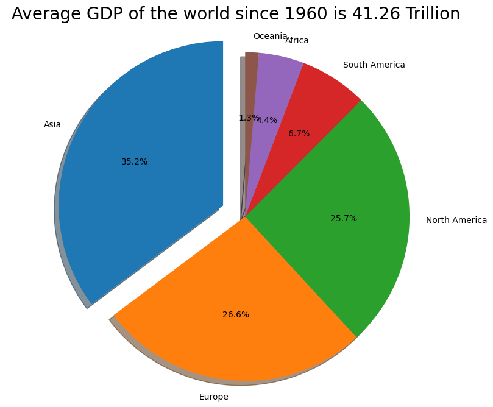

```python
explode = (0.15, 0, 0, 0,0,0)  # only "explode" the 2nd slice (i.e. 'Hogs')

fig1, ax1 = plt.subplots(figsize=(8,8))
ax1.pie(continent['gdp_in_trillions'], explode=explode, labels=continent['continent'], autopct='%1.1f%%',
        shadow=True, startangle=90)
ax1.axis('equal')  # Equal aspect ratio ensures that pie is drawn as a circle.
ax1.set_title(" Average GDP of the world since 1960 is {} Trillion".format(round(sum(continent["gdp_in_trillions"]),2)),
              fontsize=20)

plt.show()
```

### Findings from the chart

```python
cont_df=df.groupby(["country",'continent',"year"],as_index=False)["gdp_format"].sum()
cont_df["gdp_in_trillions"]=cont_df['gdp_format']/(10**12)
cont_df
```

|  | country | continent | year | gdp_format | gdp_in_trillions |
| --- | --- | --- | --- | --- | --- |
| 0 | Albania | Europe | 1980 | 1.270000e+10 | 0.0127 |
| 1 | Albania | Europe | 1981 | 1.300000e+10 | 0.0130 |
| 2 | Albania | Europe | 1982 | 1.330000e+10 | 0.0133 |
| 3 | Albania | Europe | 1983 | 1.360000e+10 | 0.0136 |
| 4 | Albania | Europe | 1984 | 1.400000e+10 | 0.0140 |
| ... | ... | ... | ... | ... | ... |
| 6026 | Zimbabwe | Africa | 2009 | 1.400000e+10 | 0.0140 |
| 6027 | Zimbabwe | Africa | 2010 | 1.530000e+10 | 0.0153 |
| 6028 | Zimbabwe | Africa | 2011 | 1.680000e+10 | 0.0168 |
| 6029 | Zimbabwe | Africa | 2012 | 1.850000e+10 | 0.0185 |
| 6030 | Zimbabwe | Africa | 2013 | 1.930000e+10 | 0.0193 |

6031 rows × 5 columns

# What is the growth like for every continents since 1960?

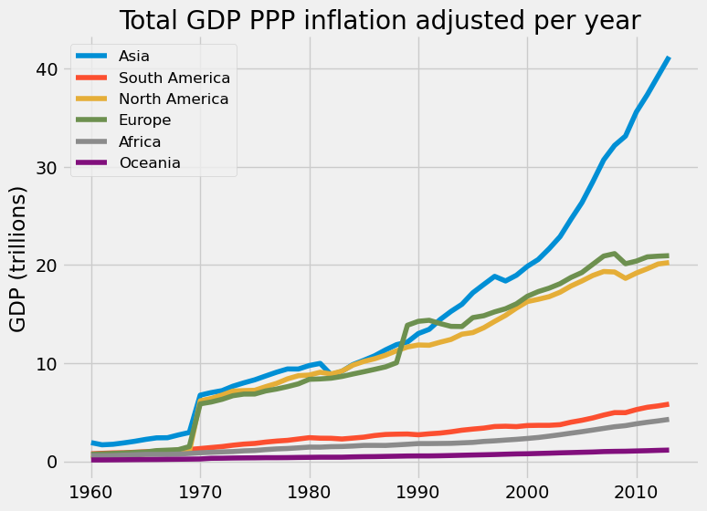

```python
plt.style.use('fivethirtyeight')
df["gdp_in_trillions"]=df['gdp_format']/(10**12)
asia=df.query("continent=='Asia'").groupby("year",as_index=False)["gdp_in_trillions"].sum()
s_america=df.query("continent=='South America'").groupby("year",as_index=False)["gdp_in_trillions"].sum()
n_america=df.query("continent=='North America'").groupby("year",as_index=False)["gdp_in_trillions"].sum()
europe=df.query("continent=='Europe'").groupby("year",as_index=False)["gdp_in_trillions"].sum()
africa=df.query("continent=='Africa'").groupby("year",as_index=False)["gdp_in_trillions"].sum()
oceania=df.query("continent=='Oceania'").groupby("year",as_index=False)["gdp_in_trillions"].sum()

fig,ax=plt.subplots(figsize=(8,6))
ax.plot(asia.year,asia["gdp_in_trillions"],label="Asia", linewidth=4)
ax.plot(s_america.year,s_america["gdp_in_trillions"],label="South America", linewidth=4)
ax.plot(n_america.year,n_america["gdp_in_trillions"],label="North America", linewidth=4)
ax.plot(europe.year,europe["gdp_in_trillions"],label="Europe", linewidth=4)
ax.plot(africa.year,africa["gdp_in_trillions"],label="Africa", linewidth=4)
ax.plot(oceania.year,oceania["gdp_in_trillions"],label="Oceania", linewidth=4)
ax.set_title("Total GDP PPP inflation adjusted per year")

ax.set_ylabel("GDP (trillions)")

ax.spines["right"].set_visible(False)
ax.spines['top'].set_visible(False)
plt.legend( fontsize=12)
plt.show()
```

## Findings

> Overall, all the continents showed an upward trend in economic growth throughout the period. However, `Asia`, `Europe` and `North America` experienced a surge in GDP growth since 1970 and have made dramatic progress over the years. A more recent study by [statistics Times](https://statisticstimes.com/economy/continents-by-gdp.php#:~:text=Asia%20is%20the%20largest%20continental,%2468.7%20trillion.) reveals similar trends.

> Between 1970 and 1990, Asia led North America and Europe marginally. However, in 1990 and beyond, economic growth appereared to be overwhelmingly in support of the `Asian` continent. It will be crucial to find out what played out that Asia displayed sucha remarkable growth in that period. The graph clearly suggests something different about economic activities in Asia compared to the rest of the world.

> It will be necessary to grill down to the key economic metrics of the continents. Perhaps, it will become clear what the Asian continent had found out and had improved on

# How do the continents differ in terms of export, industry and investments?

In this part of the project, certain key economic contributors to the GDP will be invesigated to reveal the economic strength of each continent. They include:`Export`, `Industry`, `Investment` and `Services`. They have been selected because in theory they contribute positively to GDP unlike `Import` that has negative effect on GDP. in other words, the governments spend on every import to their country which has a negative feedback on GDP.

Although `Agriculture` has a positive impact on GDP, it will not be considered in this case because `Agro` is part of a nation's export.

```python
table = df.groupby('continent').mean()
table = table.iloc[:, 3:7].reset_index()
table = table.melt(id_vars='continent', var_name='sector', value_name='percentage')
table.head()
```

|  | continent | sector | percentage |
| --- | --- | --- | --- |
| 0 | Africa | export | 25.670428 |
| 1 | Asia | export | 33.039057 |
| 2 | Europe | export | 37.717855 |
| 3 | North America | export | 33.453587 |
| 4 | Oceania | export | 28.397561 |

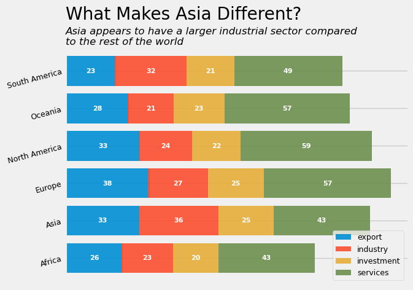

```python
plt.style.use('fivethirtyeight')
temp = np.full((6,), 0)
for s in table['sector'].unique():
    sector_data = table.query("sector == @s")
    p=plt.barh(sector_data['continent'], sector_data['percentage'], label=s, left=temp, alpha=0.9)
    plt.bar_label(p,label_type='center',size=8, color='w', fmt= "%.0f", fontweight='bold')
    plt.xticks([])
    plt.yticks(fontsize=9, rotation=15)
    temp += sector_data.percentage.reset_index(drop=True)
    plt.title('What Makes Asia Different?', loc='left', pad=30)
plt.text(x=0, y=5.7, s='Asia appears to have a larger industrial sector compared\nto the rest'+
        ' of the world', fontsize=12, fontstyle='italic')
sns.despine(bottom=True)

plt.legend(loc=4, fontsize=9)
plt.show()
```

### Findings

> It is best at this point to narrown down the study down to the countries contributing maximally to the Asian GDP. Let's find out who they are and what they do best.

# Are the top Asian countries also leaders in Industry?

#### Probable expectation: Top industrialized countries in Asia are leading in GDP

```python
#filter out every other coninent except Asia
asia = df.query("continent == 'Asia'")
means = asia.groupby('country').mean()
asia_gdp = means.sort_values(by='gdp_in_trillions', ascending=False)
asia_industry = means.sort_values(by='industry', ascending=False)


top_10_gdp = asia_gdp.head(10)['gdp_in_trillions'].sort_values() #top 10 Asian countries leading in GDP
top_10_industry = asia_industry.head(10)['industry'].sort_values()#top 10 Asian countries leading in industry
```

### Commonalities between top the top 10 big players according to GDP and top 10 industry leaders

```python
commonalities=np.intersect1d(top_10_gdp.index,top_10_industry.index)
commonalities
```

```
array(['China', 'Saudi Arabia'], dtype=object)
```

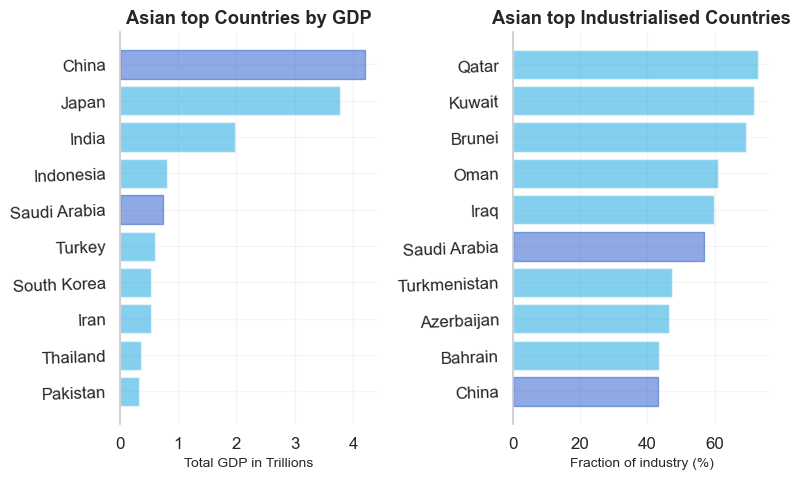

```python
sns.set(style='whitegrid', palette="deep", font_scale=1.1, rc={"figure.figsize": [8, 5]})

fig,ax=plt.subplots(1,2)
p1=ax[0].barh(top_10_gdp.index,top_10_gdp.values,color='#0AA1DD',alpha=0.5)
p2=ax[1].barh(top_10_industry.index,top_10_industry.values,color='#0AA1DD',alpha=0.5)
##ax[0].set_xticks([])
#ax[1].set_xticks([])
ax[0].set_yticks(top_10_gdp.index)
ax[0].set_yticklabels(top_10_gdp.index,rotation=2)
ax[0].set_title("Asian top Countries by GDP",fontweight='bold')
ax[1].set_title("Asian top Industrialised Countries",fontweight='bold')


ax[1].set_yticks(top_10_industry.index)
ax[1].set_yticklabels(top_10_industry.index,rotation=2)

ax[0].set_xlabel("Total GDP in Trillions",fontsize=10)
ax[1].set_xlabel("Fraction of industry (%)",fontsize=10)

p1[9].set_color("#2155CD")
p1[5].set_color("#2155CD")

p2[0].set_color("#2155CD")
p2[4].set_color("#2155CD")



ax[0].grid(False)
ax[1].grid(False)
plt.tight_layout()
sns.despine(bottom=True)
ax[1].grid(alpha=0.2)
ax[0].grid(alpha=0.2)


plt.show()
```

## Outcome of the Guess

> In contrast to the previous hypothesis that most industrialized countries are also the top leaders in GDP, It turned out that just two contries namely `China` and `Saudi Arabia` were on the two top lists throughout the period. Regarding the top industrialized Asian countries, a sudy by [NS Energy](https://www.nsenergybusiness.com/features/newstop-ten-countries-with-worlds-largest-oil-reserves-5793487/) showed that `Saudi Arabia`, `Kuwait`,`Saudi Arabia`, `Iraq` were among the top 10 oil producing countries in 2019 which buttress the fact that Asian industrial sector could have been on receiving economic boost supplied by oil producing nations as oppossed to others leading by GDP

## Conclusions

Broadly speaking, in all the counteries there have been an increase in economic activities leading to econmic growth over the years. However, the growth varied from one continent to the other. It's also found that economic concentartion of individual countries have an overall impact on their continent.

## Limitations

- The variables in consideration namely `Exports`, `Industry`,`Investment`, and `Indusrty` were expressed as mere percentage of their GDP and not the actual figures which makes it difficult to pin point by how much the continents/countries varied from one sector to the others because there are other metrics invloved in GDP calculation.
- If the actual fiures were used, incorperating population into the dataset would have revealed a lot more variations in all the continents.

```python
from subprocess import call
call(['python', '-m', 'nbconvert', 'Investigate_a_Dataset.ipynb'])
```

```
1
```